# Simulating_from_the_Null-zh

### 基于零假设的数值模拟

导入下面的数据，并按照以下问题回答下面的测试题目。

```python
import pandas as pd
import numpy as np
import matplotlib.pyplot as plt

%matplotlib inline
np.random.seed(42)

full_data = pd.read_csv('coffee_dataset.csv')
sample_data = full_data.sample(200)
```

`1.` 如果你想知道喝咖啡的人的平均身高是否与不喝咖啡的人的平均身高相等，那么，你的零假设和备择假设是什么？将它们放在下面的单元格中，并使用你的答案来回答下面的第一个测试题目。

`2.` 如果你想知道喝咖啡的人的平均身高是否低于不喝咖啡的人的身高，那么，你的零假设和备择假设是什么？将它们放在下面的单元格中，并使用你的答案来回答下面的第二个测试题目。

`3.` 对于10,000次迭代：自展程序会对样本数据进行抽样，计算喝咖啡的人和不喝咖啡的人的平均身高，并计算每个样本的平均差异。你要在迭代结束时获取三个数组 - 一个是每个平均值，一个是所有平均值的差异。使用你的抽样分布结果，回答下面的第三个测试题目。

```python
sample_data.head()
```

|  | user_id | age | drinks_coffee | height |
| --- | --- | --- | --- | --- |
| 2402 | 2874 | <21 | True | 64.357154 |
| 2864 | 3670 | >=21 | True | 66.859636 |
| 2167 | 7441 | <21 | False | 66.659561 |
| 507 | 2781 | >=21 | True | 70.166241 |
| 1817 | 2875 | >=21 | True | 71.369120 |

```python
#1.
H0:μcoff−μno=0
H1:μcoff−μno≠0
```

```python
#2.
H0:μcoff−μno≥0
H1:μcoff−μno<0
```

```python
#3.
nocoff_means, coff_means, diffs = [], [], []

for _ in range(10000):
    bootsamp = sample_data.sample(200, replace = True)
    coff_mean = bootsamp[bootsamp['drinks_coffee'] == True]['height'].mean()
    nocoff_mean = bootsamp[bootsamp['drinks_coffee'] == False]['height'].mean()
    # append the info
    coff_means.append(coff_mean)
    nocoff_means.append(nocoff_mean)
    diffs.append(coff_mean - nocoff_mean)
```

```python
np.std(nocoff_means) # the standard deviation of the sampling distribution for nocoff
```

```
0.40512631277475247
```

```python
np.std(coff_means) # the standard deviation of the sampling distribution for coff
```

```
0.24073763373472962
```

```python
np.std(diffs) # the standard deviation for the sampling distribution for difference in means
```

```
0.4698091074387144
```

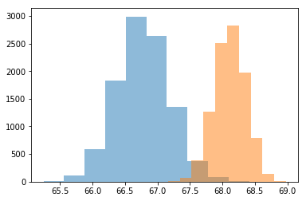

```python
plt.hist(nocoff_means, alpha = 0.5);
plt.hist(coff_means, alpha = 0.5); # They look pretty normal to me!
```

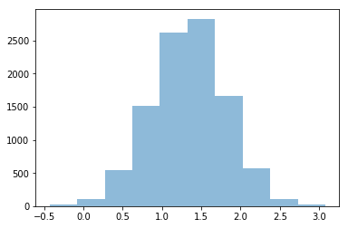

```python
plt.hist(diffs, alpha = 0.5); # again normal - this is by the central limit theorem
```

```python
#4
null_vals = np.random.normal(0, np.std(diffs), 10000) # Here are 10000 draws from the sampling distribution under the null
```

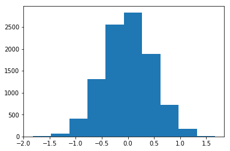

```python
plt.hist(null_vals); #Here is the sampling distribution of the difference under the null
```